# Assignment 1: Clustering

### 15. For Account: US News Health

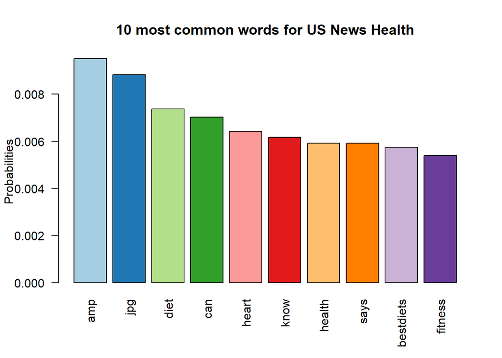

```r
dtm <- TermDocumentMatrix(tweetsData[15])
m <- as.matrix(dtm)
v <- sort(rowSums(m),decreasing=TRUE)
d <- data.frame(word = names(v),freq=v)

barplot(d[1:10,]$freq/sum(d$freq), las = 2, names.arg = d[1:10,]$word,
        col = brewer.pal(10, "Paired"), main ="10 most common words for US News Health",
        ylab = "Probabilities")
```

### 16. For Account: WSJ Health

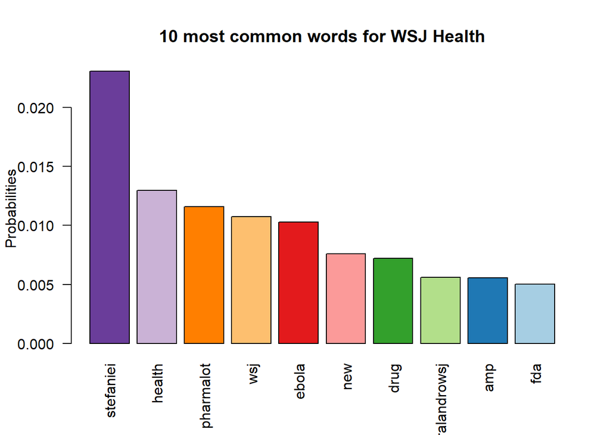

```r
dtm <- TermDocumentMatrix(tweetsData[16])
m <- as.matrix(dtm)
v <- sort(rowSums(m),decreasing=TRUE)
d <- data.frame(word = names(v),freq=v)

barplot(d[1:10,]$freq/sum(d$freq), las = 2, names.arg = d[1:10,]$word,
        col = rev(brewer.pal(10, "Paired")), main ="10 most common words for WSJ Health",
        ylab = "Probabilities")
```

Based on the above output, we can observe more health realted words showing up in all the accounts after data cleaning.

Now, we will now merge the tweets from all the account and cluster them using **k-means** clustering algorithm.

We will cluster the tweets using two methods:

- Using the distance between words frequencies in Document Term Matrix
- Using the distance between word vectors using Glove embeddings